# Aula 1 - Semana 1

Ivanildo Batista

8 de fevereiro de 2021

## Curso Financial Risk Management with R - Semana 1

### Retrieving Data from FRED (Aula 1)

O objetivo dessa aula e extrair dados do FRED, que uma base de dados do FED (conjunto de banco que orientam a politica monetaria americana). Essa base de dados compreende dados macroeconomicos (como PIB, oferta de monetaria, inflacao, etc), dados setorias, dados populacionais e de outros tipos.

Agora irei instalar a biblioteca QUANTMOD para realizar a extracao de dados que temos interesse:

```r
library(quantmod)
```

**Indice WILLSHIRE 5000 TOTAL MARKET INDEX**

Irei extrair o indice Wilshire 5000 que e um indice que representa um portfolio que investe em acoes de todas as empresas negociadas nos Estados Unidos da America.Os dados dessa serie sao diarios e vao dos anos de 1971 ate 2017. Usando a biblioteca QUANTMOD irei importar os dados desse indice apara uma variavel, conforme abaixo:

```r
wilsh = getSymbols("WILL5000IND", src = "FRED", auto.assign = FALSE)
```

[output not shown]

Visualizando a serie em uma tabela:

```r
View(wilsh)
```

A serie de dados pode apresentar dados faltantes, principalmente por ter periodos que nao foram registrados, que sao os casos de sabados e domingos. Por isso os dados do tipo NA serao removidos. Antes irei verificar se ha dados faltantes:

```r
sum(is.na(wilsh))
```

```
## [1] 2581
```

Vemos que temos 2581 dados faltantes, entao eles serao removidos:

```r
wilsh = na.omit(wilsh)
```

Verificando novamente se ha dados faltantes:

```r
sum(is.na(wilsh))
```

```
## [1] 0
```

```r
wilsh = wilsh['1979-12-31/2017-12-31']
```

Renomeando a variavel:

```r
names(wilsh) = "TR"
```

Visualizando as primeiras linhas

```r
head(wilsh)
```

```
##              TR
## 1979-12-31 1.90
## 1980-01-02 1.86
## 1980-01-04 1.88
## 1980-01-07 1.89
## 1980-01-08 1.93
## 1980-01-09 1.93
```

Visualizando as ultimas linhas

```r
tail(wilsh)
```

```
##                TR
## 2017-12-21 124.10
## 2017-12-22 124.03
## 2017-12-26 123.94
## 2017-12-27 124.04
## 2017-12-28 124.33
## 2017-12-29 123.67
```

Percebemos que do comeco da nossa serie ate o seu final, houve um aumento medio de 65 vezes do valor desse indice, porem isso nao foi de forma instantanea. No grafico abaixo podemos ver a trajetoria do indice ao longo do tempo e que ha muito altos e baixos.

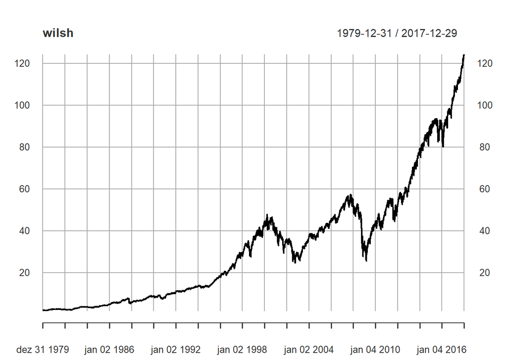

```r
plot(wilsh)
```